# Activity Analyser

Somesh Verma

September 10, 2016

## Introduction

It is now possible to collect a large amount of data about personal movement using activity monitoring devices such as a Fitbit, Nike Fuelband, or Jawbone Up. These type of devices are part of the “quantified self” movement - a group of enthusiasts who take measurements about themselves regularly to improve their health, to find patterns in their behavior, or because they are tech geeks. But these data remain under-utilized both because the raw data are hard to obtain and there is a lack of statistical methods and software for processing and interpreting the data.

This assignment makes use of data from a personal activity monitoring device. This device collects data at 5 minute intervals through out the day. The data consists of two months of data from an anonymous individual collected during the months of October and November, 2012 and include the number of steps taken in 5 minute intervals each day.

The data for this assignment can be downloaded from the course web site:

Dataset: [Activity monitoring data](https://d396qusza40orc.cloudfront.net/repdata%2Fdata%2Factivity.zip)

The variables included in this dataset are:

- steps: Number of steps taking in a 5-minute interval (missing values are coded as NA)
- date: The date on which the measurement was taken in YYYY-MM-DD format
- interval: Identifier for the 5-minute interval in which measurement was taken

### Data Load

Load the data using read.csv/tbl_df and for understanding of data, lets print the o/p of summary

```r
library(dplyr)
library(lattice)

activityData <- tbl_df(read.csv(file = "activity.csv", na.strings = "NA"))
summary(activityData)
```

```
##      steps                date          interval
##  Min.   :  0.00   2012-10-01:  288   Min.   :   0.0
##  1st Qu.:  0.00   2012-10-02:  288   1st Qu.: 588.8
##  Median :  0.00   2012-10-03:  288   Median :1177.5
##  Mean   : 37.38   2012-10-04:  288   Mean   :1177.5
##  3rd Qu.: 12.00   2012-10-05:  288   3rd Qu.:1766.2
##  Max.   :806.00   2012-10-06:  288   Max.   :2355.0
##  NA's   :2304     (Other)   :15840
```

### What is mean total number of steps taken per day?

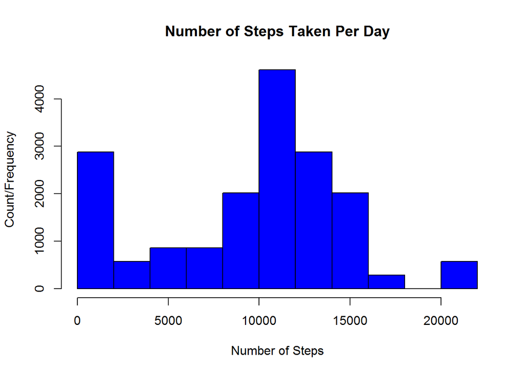

```r
activityDataDate <- activityData %>%
    group_by(date) %>%
      mutate(totalSteps=sum(steps, na.rm=T))
hist(activityDataDate$totalSteps, col="blue",
    main="Number of Steps Taken Per Day", xlab="Number of Steps",
    ylab="Count/Frequency", breaks=10)
```

#### Mean and Median of the Daily Step Count

```r
sprintf("Mean of Total Steps: %f Median of Total Steps: %f", mean(activityDataDate$totalSteps), median(activityDataDate$totalSteps))
```

```
## [1] "Mean of Total Steps: 9354.229508 Median of Total Steps: 10395.000000"
```

### What is the average daily activity pattern?

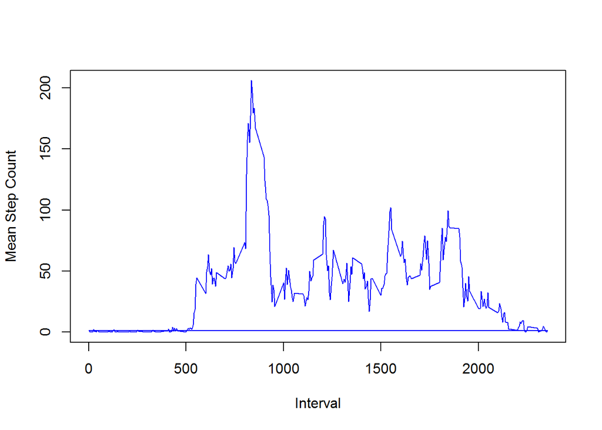

```r
activityPattern <- activityData %>%
    group_by(interval) %>%
      mutate(meanSteps=mean(steps, na.rm=T))
plot(activityPattern$interval, activityPattern$meanSteps, type="l", col="blue", xlab = "Interval", ylab = "Mean Step Count")
```

```r
maximumInterval<- which.max(activityPattern$meanSteps)
activityPattern[maximumInterval, ]
```

```
## Source: local data frame [1 x 4]
## Groups: interval [1]
##
##   steps       date interval meanSteps
##   <int>     <fctr>    <int>     <dbl>
## 1    NA 2012-10-01      835  206.1698
```

### Imputing missing values

#### 1. Calculate and report the total number of missing values in the dataset (i.e. the total number of rows with NAs)

```r
sprintf("Number of Rows with NA: %d", sum(is.na(activityData)))
```

```
## [1] "Number of Rows with NA: 2304"
```

#### 2. Devise a strategy for filling in all of the missing values in the dataset. The strategy does not need to be sophisticated. For example, you could use the mean/median for that day, or the mean for that 5-minute interval, etc.

#### 3. Create a new dataset that is equal to the original dataset but with the missing data filled in.

```r
activityDataImput <- activityData %>%
    group_by(interval) %>%
    mutate(steps=ifelse(is.na(steps), mean(steps, na.rm=T), steps))
```

[figure not shown]

```r
activityDataDate <- activityData %>%
    group_by(date) %>%
      mutate(totalSteps=sum(steps, na.rm=T))
hist(activityDataDate$totalSteps, col="blue",
    main="Number of Steps Taken Per Day", xlab="Number of Steps",
    ylab="Count/Frequency", breaks=10)
```

### Are there differences in activity patterns between weekdays and weekends?

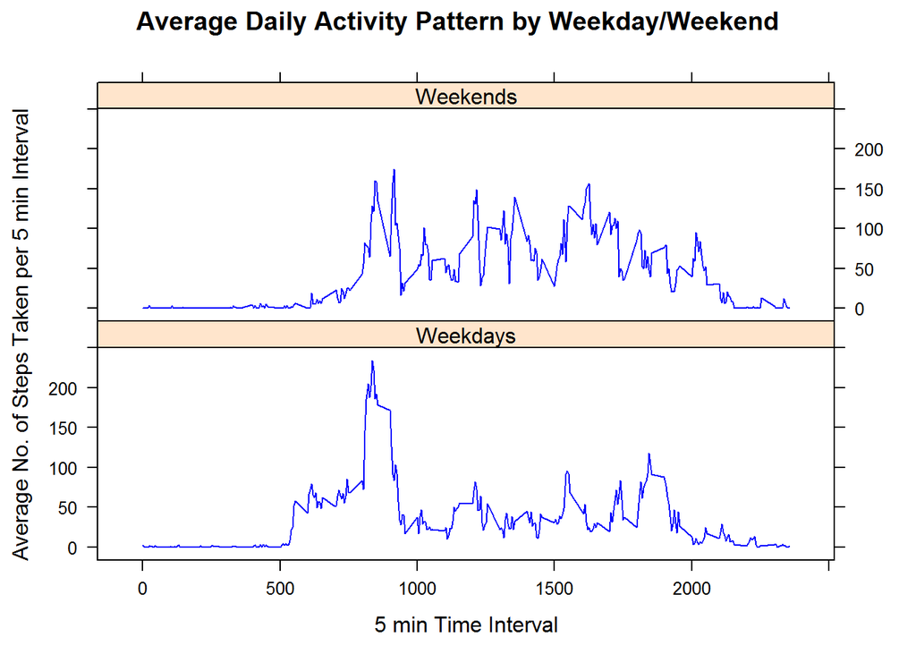

```r
activityDataWeekdays <- activityData %>%
    mutate(weekdays=ifelse((weekdays(as.Date(as.character(date)),T) == "Sun") | (weekdays(as.Date(as.character(date)), T) == "Sat"),"Weekends","Weekdays"))

activityDataWeekdaysSummary <- activityDataWeekdays %>%
  group_by(weekdays, interval)  %>%
  summarize(totalSteps=sum(steps, na.rm=TRUE), averageSteps=mean(steps, na.rm=TRUE))


xyplot(averageSteps~interval|weekdays, data=activityDataWeekdaysSummary, type='l', layout=(c(1,2)),
   main="Average Daily Activity Pattern by Weekday/Weekend", col="blue",
   ylab="Average No. of Steps Taken per 5 min Interval", xlab="5 min Time Interval")
```